Universidad El Bosque

Diseño de Experimentos

Sesión 1 de 2 · 90 min

# Diseños en bloques completos al azar

Por qué bloquear, cómo se aleatoriza y cómo se lee la tabla

Factor perturbadorAleatorización restringidaModelo aditivoTabla ANOVACon y sin bloques

**Javier Mauricio Sierra**

Universidad El Bosque

Diseño de Experimentos

Capítulo 5 · Diseños en bloques completos al azar

Por qué bloquear

Aleatorización restringida

El modelo y la suma de cuadrados

La tabla ANOVA

Con y sin bloques

Cierre y práctica

Hoja de ruta

## Lo que vamos a construir hoy

Objetivo de la sesión

Reconocer un factor perturbador que se puede bloquear, construir un DBCA con su aleatorización restringida y leer su tabla ANOVA sabiendo qué pasa cuando el bloque se ignora.

Factor perturbadorAleatorización restringidaModelo aditivoTabla ANOVACon y sin bloques

2 / 36

Universidad El Bosque

Diseño de Experimentos

Capítulo 5 · Diseños en bloques completos al azar

Por qué bloquear

Aleatorización restringida

El modelo y la suma de cuadrados

La tabla ANOVA

Con y sin bloques

Cierre y práctica

01

## Por qué bloquear

Hasta ahora supusimos que daba igual a qué tubo, a qué oblea o a qué paciente le tocaba cada tratamiento. Casi nunca da igual.

Leer en el material: 5.1 Por qué bloquear: el ruido que se puede nombrar

3 / 36

Por qué bloquear

## Lo que se hace con un factor perturbador depende de lo que sepas de él

### Desconocido

No se le puede apuntar. Lo único que protege es la **aleatorización**, que reparte su efecto por igual entre los tratamientos.

### Conocido y medible

Se registra y se descuenta en el análisis con una covariable: el **análisis de covarianza**, fuera de este curso.

### Conocido y controlable

Se elige en qué nivel corre cada unidad. Entonces se **bloquea**, y de eso va el capítulo.

Capítulo 5 · Diseños en bloques completos al azarDiseño de Experimentos · UnBosque4 / 36

Por qué bloquear

## El injerto vascular: cuatro presiones de extrusión, seis lotes de resina

|  | Lote 1 | Lote 2 | Lote 3 | Lote 4 | Lote 5 | Lote 6 | Media |
| --- | --- | --- | --- | --- | --- | --- | --- |
| 8500 psi | 90.3 | 89.2 | 98.2 | 93.9 | 87.4 | 97.9 | 92.817 |
| 8700 psi | 92.5 | 89.5 | 90.6 | 94.7 | 87.0 | 95.8 | 91.683 |
| 8900 psi | 85.5 | 90.8 | 89.6 | 86.2 | 88.0 | 93.4 | 88.917 |
| 9100 psi | 82.5 | 89.5 | 85.6 | 87.4 | 78.9 | 90.7 | 85.767 |
| **Media** | 87.700 | 89.750 | 91.000 | 90.550 | **85.325** | **94.450** | 89.796 |

Rendimiento: % de tubos sin defectos de superficie. Mira las columnas: el **lote 6** es alto en las cuatro presiones y el **lote 5**, bajo en las cuatro.

Capítulo 5 · Diseños en bloques completos al azarDiseño de Experimentos · UnBosque5 / 36

Por qué bloquear

## Los lotes se separan más que las presiones

- Rango entre las medias de presión: **7.050** puntos
- Rango entre las medias de lote: **9.125** puntos
- Los lotes se llevan **192.25 de 480.31**: el **40.03 %** de la variabilidad total

En un diseño completamente al azar, ese 40 % iría entero al error.

Capítulo 5 · Diseños en bloques completos al azarDiseño de Experimentos · UnBosque6 / 36

Idea clave

## Bloquear no elimina variabilidad: la cambia de sitio

Del denominador del \(F\) a una fila propia de la tabla. Sin bloquear, el error carga con \(\sigma^2_\beta + \sigma^2\); bloqueando, solo con \(\sigma^2\).

Capítulo 5 · Diseños en bloques completos al azarDiseño de Experimentos · UnBosque7 / 36

Pregunta para la clase

## ¿Qué hace el ingeniero con la colada?

Cuatro recubrimientos anticorrosión y veinte probetas de **cinco coladas** de acero, cuatro por colada. Las coladas difieren en dureza, y él elige qué probeta recibe cada recubrimiento.

1. Aleatorizar las veinte: la aleatorización ya protege.
2. Medir la dureza y usarla como covariable.
3. Quedarse con las probetas más homogéneas.
4. Bloquear por colada.

4 · Bloquear por colada

Conocido y controlable: es la casilla del bloqueo. La 1 protege del sesgo, no de la varianza; la 2 es para lo que no se puede elegir; la 3 estrecha el alcance del experimento.

Capítulo 5 · Diseños en bloques completos al azarDiseño de Experimentos · UnBosque8 / 36

Universidad El Bosque

Diseño de Experimentos

Capítulo 5 · Diseños en bloques completos al azar

Por qué bloquear

Aleatorización restringida

El modelo y la suma de cuadrados

La tabla ANOVA

Con y sin bloques

Cierre y práctica

02

## Aleatorización restringida

Bloquear no es dejar de aleatorizar: es aleatorizar dentro de cada bloque.

Leer en el material: 5.2 Aleatorización restringida: cómo se construye un DBCA

9 / 36

Aleatorización restringida

## Un DBCA sortea dentro de cada bloque, y cada tratamiento va una vez por bloque

Una permutación por lote

```
set.seed(2026)
plan <- t(sapply(1:6, function(j) sample(4)))
dimnames(plan) <- list(paste("Lote", 1:6), paste("Unidad", 1:4))
plan
#>        Unidad 1 Unidad 2 Unidad 3 Unidad 4
#> Lote 1        1        4        3        2
#> Lote 2        1        3        4        2
#> Lote 3        4        1        3        2
#> Lote 4        2        4        3        1
#> Lote 5        3        1        2        4
#> Lote 6        4        2        3        1
```

- **Completo**: cada bloque contiene una réplica completa del experimento
- El orden dentro del lote sigue siendo aleatorio
- La aleatorización está **restringida**, y esa restricción es todo el diseño

Capítulo 5 · Diseños en bloques completos al azarDiseño de Experimentos · UnBosque10 / 36

Pregunta para la clase

## ¿Cuántas celdas quedan vacías si se ignoran los lotes?

Cuatro tratamientos, seis lotes: 24 celdas tratamiento × lote. Repartimos las 24 unidades **completamente al azar**, sin respetar los lotes, y lo repetimos 5000 veces.

Respuesta

En promedio, **6.91 de 24**. En las 5000 de R ni una sola salió balanceada: la probabilidad es \(8.28\times10^{-5}\). Una celda vacía es un tratamiento que nunca se probó en ese lote, y su comparación queda confundida con el lote.

Capítulo 5 · Diseños en bloques completos al azarDiseño de Experimentos · UnBosque11 / 36

Aleatorización restringida

## `design.rcbd()` cambia el generador de la sesión y no lo devuelve

El plan con agricolae

```
library(agricolae)
trt <- 1:4
estado <- .Random.seed
libro <- design.rcbd(trt, r = 6, seed = 2026, serie = 1)$book
RNGkind()[1]
#> [1] "Super-Duper"
assign(".Random.seed", estado, envir = .GlobalEnv)
RNGkind()[1]
#> [1] "Mersenne-Twister"
```

Por dentro ejecuta `set.seed(seed, kinds)`: a partir de ahí, cualquier `set.seed(k)` da **otro flujo** que en una sesión limpia.

Guardar `.Random.seed` antes y devolverlo después restaura el tipo **y** el estado.

Capítulo 5 · Diseños en bloques completos al azarDiseño de Experimentos · UnBosque12 / 36

Universidad El Bosque

Diseño de Experimentos

Capítulo 5 · Diseños en bloques completos al azar

Por qué bloquear

Aleatorización restringida

El modelo y la suma de cuadrados

La tabla ANOVA

Con y sin bloques

Cierre y práctica

03

## El modelo y la suma de cuadrados

El modelo del capítulo 2, con un término más.

Leer en el material: 5.3 El modelo del DBCA y la descomposición de la suma de cuadrados

13 / 36

El modelo y la suma de cuadrados

## El modelo del DBCA suma un efecto de bloque al del DCA

$$y_{ij} = \mu + \tau_i + \beta_j + \varepsilon_{ij}, \qquad \varepsilon_{ij} \sim \text{NID}(0, \sigma^2)$$

- \(\tau_i\): efecto del tratamiento \(i = 1, \dots, a\), con \(\sum_i \tau_i = 0\)
- \(\beta_j\): efecto del bloque \(j = 1, \dots, b\), con \(\sum_j \beta_j = 0\)

Las dos restricciones hacen identificables los \(1 + a + b\) parámetros.

Capítulo 5 · Diseños en bloques completos al azarDiseño de Experimentos · UnBosque14 / 36

El modelo y la suma de cuadrados

## Tres cosas que decir del modelo antes de tocarlo

### Es aditivo

Pasar de 8500 a 9100 psi tiene el mismo efecto en todos los lotes. Si no, hay interacción (módulo 5.8).

### Una observación por celda

No hay réplica genuina: el error sale del residuo de la aditividad. Por eso la aditividad no es negociable.

### El bloque no interesa

Formalmente es un factorial sin réplica, pero nadie va a recomendar «use el lote 6».

Capítulo 5 · Diseños en bloques completos al azarDiseño de Experimentos · UnBosque15 / 36

El modelo y la suma de cuadrados

## El valor ajustado ya no es la media del tratamiento: lleva la corrección del bloque

$$\hat y_{ij} = \bar y_{i.} + \bar y_{.j} - \bar y_{..}$$

con \(\hat\mu = \bar y_{..}\), \(\hat\tau_i = \bar y_{i.} - \bar y_{..}\) y \(\hat\beta_j = \bar y_{.j} - \bar y_{..}\).

En el injerto, \(\hat\beta_6 = +4.65\) y \(\hat\beta_5 = -4.47\): entre esos dos lotes hay más distancia que entre la mejor y la peor presión.

Capítulo 5 · Diseños en bloques completos al azarDiseño de Experimentos · UnBosque16 / 36

Pregunta para la clase

## ¿Cuánto vale el ajustado de 8500 psi en el lote 1?

Con \(\bar y_{1.} = 92.817\), \(\bar y_{.1} = 87.700\) y \(\bar y_{..} = 89.796\), y la observación \(y_{11} = 90.3\): ¿cuánto valen el ajustado y el residuo?

Respuesta

\(\hat y_{11} = 92.817 + 87.700 - 89.796 = 90.721\), y el residuo, \(e_{11} = 90.3 - 90.721 = -0.421\). En un DCA el ajustado habría sido 92.817.

Capítulo 5 · Diseños en bloques completos al azarDiseño de Experimentos · UnBosque17 / 36

El modelo y la suma de cuadrados

## Al elevar al cuadrado, los productos cruzados valen cero, no «casi cero»

$$y_{ij} - \bar y_{..} = \underbrace{(\bar y_{i.} - \bar y_{..})}_{\hat\tau_i} + \underbrace{(\bar y_{.j} - \bar y_{..})}_{\hat\beta_j} + \underbrace{(y_{ij} - \bar y_{i.} - \bar y_{.j} + \bar y_{..})}_{e_{ij}}$$

$$SS_T = SS_{\text{Trat}} + SS_{\text{Bloques}} + SS_E$$

En el injerto, \(480.310 = 178.171 + 192.252 + 109.886\). Lo que R imprime para los productos cruzados, del orden de \(10^{-14}\), es redondeo de coma flotante.

Capítulo 5 · Diseños en bloques completos al azarDiseño de Experimentos · UnBosque18 / 36

El modelo y la suma de cuadrados

## Hay observaciones que se alejan casi solo por su lote, y otras casi solo por su presión

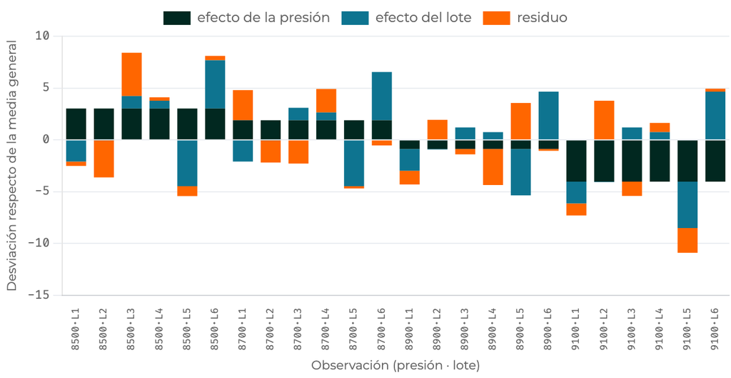

La desviación de cada observación, partida en efecto de presión, efecto de lote y residuo

Capítulo 5 · Diseños en bloques completos al azarDiseño de Experimentos · UnBosque19 / 36

Universidad El Bosque

Diseño de Experimentos

Capítulo 5 · Diseños en bloques completos al azar

Por qué bloquear

Aleatorización restringida

El modelo y la suma de cuadrados

La tabla ANOVA

Con y sin bloques

Cierre y práctica

04

## La tabla ANOVA

Con la identidad y los grados de libertad contados, la tabla se escribe sola.

Leer en el material: 5.4 La tabla ANOVA y el estadístico F

20 / 36

La tabla ANOVA

## La tabla ANOVA del DBCA tiene una fila más que la del DCA

| Fuente | Suma de cuadrados | gl | Cuadrado medio | \(F_0\) |
| --- | --- | --- | --- | --- |
| Tratamientos | \(SS_{\text{Trat}}\) | \(a - 1\) | \(MS_{\text{Trat}}\) | \(MS_{\text{Trat}}/MS_E\) |
| Bloques | \(SS_{\text{Bloques}}\) | \(b - 1\) | \(MS_{\text{Bloques}}\) | — |
| Error | \(SS_E\) | \((a-1)(b-1)\) | \(MS_E\) |  |
| Total | \(SS_T\) | \(ab - 1\) |  |  |

Los \(b - 1\) grados de libertad del bloque **salen del error**: es lo que cuesta bloquear.

Capítulo 5 · Diseños en bloques completos al azarDiseño de Experimentos · UnBosque21 / 36

La tabla ANOVA

## El multiplicador es \(b\): donde el capítulo 3 decía \(n\), aquí va \(b\)

$$E[MS_{\text{Trat}}] = \sigma^2 + \frac{b\sum_i \tau_i^2}{a-1}, \qquad E[MS_E] = \sigma^2$$

Bajo \(H_0: \tau_1 = \dots = \tau_a = 0\), el cociente sigue una \(F_{a-1,\,(a-1)(b-1)}\). Si algún \(\tau_i \neq 0\), crece: la prueba es de **una cola**.

Capítulo 5 · Diseños en bloques completos al azarDiseño de Experimentos · UnBosque22 / 36

La tabla ANOVA

## En el injerto la presión importa: \(F_0 = 8.11\) contra un crítico de 3.29

R

```
injerto <- data.frame(
  presion = factor(rep(c(8500, 8700, 8900, 9100), each = 6)),
  lote    = factor(rep(1:6, times = 4)),
  y       = c(90.3, 89.2, 98.2, 93.9, 87.4, 97.9,
              92.5, 89.5, 90.6, 94.7, 87.0, 95.8,
              85.5, 90.8, 89.6, 86.2, 88.0, 93.4,
              82.5, 89.5, 85.6, 87.4, 78.9, 90.7))
ajuste <- aov(y ~ presion + lote, data = injerto)
summary(ajuste)
#>             Df Sum Sq Mean Sq F value  Pr(>F)
#> presion      3  178.2   59.39   8.107 0.00192 **
#> lote         5  192.2   38.45   5.249 0.00553 **
#> Residuals   15  109.9    7.33
```

Con \(p = 0.0019\). El modelo explica el **77.1 %** de la variabilidad, y la desviación residual es de 2.71 puntos.

Capítulo 5 · Diseños en bloques completos al azarDiseño de Experimentos · UnBosque23 / 36

Pregunta para la clase

## ¿Qué dice la fila de los lotes?

R imprime también \(F = 5.25\) y \(p = 0.0055\) para los lotes. ¿Cómo se lee?

1. Los lotes difieren significativamente, con la misma validez que la prueba de presiones.
2. Hay que rehacer el análisis sin los lotes.
3. Es un indicador de que bloquear valió la pena, no una prueba de hipótesis.
4. Hay interacción entre lote y presión.

3 · Un indicador, no una prueba

Los lotes no se aleatorizaron: son lo que había. Sin aleatorización no hay distribución de referencia justificada.

Capítulo 5 · Diseños en bloques completos al azarDiseño de Experimentos · UnBosque24 / 36

La tabla ANOVA

## El \(F\) de bloques dice si conviene volver a bloquear; no decide nada

Por qué no es una prueba en sentido estricto

- **La aleatorización no es completa**: las presiones se sortearon dentro de cada lote, pero los lotes no se asignaron a nada.
- **No se decide a posteriori**: el bloqueo se eligió antes del experimento, y que salga o no significativo no cambia el análisis.

Lo útil: \(MS_{\text{Bloques}} = 38.45\) contra \(MS_E = 7.33\), cinco veces mayor. Con este material, **conviene volver a bloquear**.

Capítulo 5 · Diseños en bloques completos al azarDiseño de Experimentos · UnBosque25 / 36

La tabla ANOVA

## Con dos tratamientos, el DBCA es la comparación pareada

Las dos presiones extremas

```
dos <- droplevels(subset(injerto, presion %in% c("8500", "9100")))
F_dos <- anova(aov(y ~ presion + lote, data = dos))["presion", "F value"]
d <- dos$y[dos$presion == "8500"] - dos$y[dos$presion == "9100"]
d
#> [1]  7.8 -0.3 12.6  6.5  8.5  7.2
tp <- t.test(d)
round(c(F_dbca = F_dos, t_pareado = unname(tp$statistic),
        t_al_cuadrado = unname(tp$statistic)^2), 6)
#>        F_dbca     t_pareado t_al_cuadrado
#>     16.979730      4.120647     16.979730
```

\(F_0 = t_0^2\) dígito a dígito, con los mismos 5 gl y el mismo \(p = 0.0092\). **El bloque es el par.**

Capítulo 5 · Diseños en bloques completos al azarDiseño de Experimentos · UnBosque26 / 36

Universidad El Bosque

Diseño de Experimentos

Capítulo 5 · Diseños en bloques completos al azar

Por qué bloquear

Aleatorización restringida

El modelo y la suma de cuadrados

La tabla ANOVA

Con y sin bloques

Cierre y práctica

05

## Con y sin bloques

Los datos son los mismos; solo cambia el modelo que se ajusta.

Leer en el material: 5.5 El mismo experimento, con y sin bloques

27 / 36

Con y sin bloques

## Ignorar los lotes no los borra: su suma de cuadrados se muda al error

El injerto como si fuera un DCA

```
como_dca <- aov(y ~ presion, data = injerto)
summary(como_dca)
#>             Df Sum Sq Mean Sq F value Pr(>F)
#> presion      3  178.2   59.39   3.931 0.0234 *
#> Residuals   20  302.1   15.11
```

- \(SS_{\text{Trat}}\) **no cambia**: 178.171
- \(302.138 = 109.886 + 192.252\), exacto
- \(MS_E\) **se duplica**: de 7.33 a 15.11
- \(F\) de 8.11 a 3.93; \(p\) de 0.0019 a 0.0234

Capítulo 5 · Diseños en bloques completos al azarDiseño de Experimentos · UnBosque28 / 36

Pregunta para la clase

## La tabla 4.5 de Montgomery publica \(F_0 = 3.95\). ¿Errata o redondeo?

Es este mismo análisis sin bloques. La misma fila imprime \(MS_{\text{Trat}} = 59.39\), \(MS_E = 15.11\) y \(p = 0.0235\).

Errata de imprenta

\(59.39/15.11 = 3.9305\), y a 3.9305 le corresponde \(p = 0.0235\). Si fuera 3.95, el valor \(p\) sería 0.0231. **El libro se delata con su propio valor \(p\).**

Capítulo 5 · Diseños en bloques completos al azarDiseño de Experimentos · UnBosque29 / 36

Con y sin bloques

## Cuanto más pesan los lotes, más se hunde el \(F\) del DCA; el del DBCA no se mueve

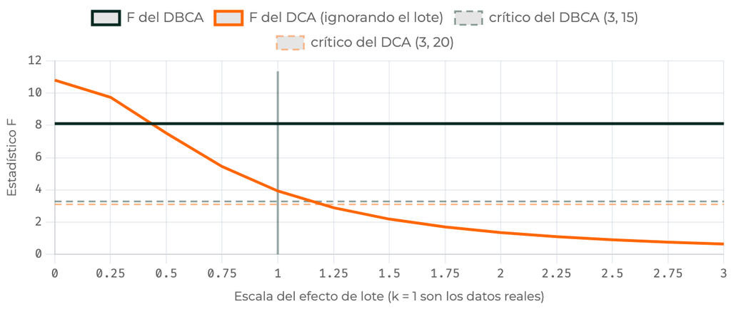

El estadístico F de los dos análisis frente a la escala del efecto de lote; k = 1 son los datos reales

Capítulo 5 · Diseños en bloques completos al azarDiseño de Experimentos · UnBosque30 / 36

Con y sin bloques

## En la dureza de puntas, ignorar el bloque da la vuelta al veredicto

Cuatro puntas de un probador de dureza, cada una sobre los **mismos cuatro cupones** metálicos: el cupón es el bloque.

|  | Cupón 1 | Cupón 2 | Cupón 3 | Cupón 4 |
| --- | --- | --- | --- | --- |
| Punta 1 | 9.3 | 9.4 | 9.6 | 10.0 |
| Punta 2 | 9.4 | 9.3 | 9.8 | 9.9 |
| Punta 3 | 9.2 | 9.4 | 9.5 | 9.7 |
| Punta 4 | 9.7 | 9.6 | 10.0 | 10.2 |

Con las cuatro puntas, el **cupón 4** da la lectura más alta.

| Análisis | \(F\) de las puntas | \(p\) | \(MS_E\) |
| --- | --- | --- | --- |
| Con los cupones | 14.44 | **0.00087** | 0.0089 |
| Sin los cupones | 1.70 | **0.22** | 0.0754 |

El cuadrado medio de los cupones es **0.275**, treinta y una veces el del error. Sin ellos, las cuatro puntas parecen equivalentes.

Capítulo 5 · Diseños en bloques completos al azarDiseño de Experimentos · UnBosque31 / 36

Pregunta para la clase

## Dureza con y sin cupones: ¿cuáles son correctas?

1. La suma de cuadrados de los cupones no desapareció: se sumó a la del error.
2. Ignorar el bloque cambia la conclusión a \(\alpha = 0.05\).
3. La diferencia estimada entre dos puntas es la misma en los dos análisis; cambia su error estándar.
4. Como el \(F\) sube de 1.70 a 14.44, el modelo con bloques ajusta mejor, y por eso se prefiere.
5. Los gl del error bajan de 12 a 9 porque se pierden tres observaciones.

1, 2 y 3

La 4 acierta en la conclusión, pero no en el argumento: se prefiere porque **así se aleatorizó**. En la 5 no se pierde ninguna observación: se gastan tres parámetros.

Capítulo 5 · Diseños en bloques completos al azarDiseño de Experimentos · UnBosque32 / 36

Idea clave

## El análisis sigue a la aleatorización, salga el \(F\) que salga

Se sorteó dentro de cada cupón, así que el análisis lleva los cupones. Añadir cualquier término sube el \(F\): lo que justifica este no es el \(F\), es el diseño.

Capítulo 5 · Diseños en bloques completos al azarDiseño de Experimentos · UnBosque33 / 36

Universidad El Bosque

Diseño de Experimentos

Capítulo 5 · Diseños en bloques completos al azar

Por qué bloquear

Aleatorización restringida

El modelo y la suma de cuadrados

La tabla ANOVA

Con y sin bloques

Cierre y práctica

06

## Cierre y práctica

Leer en el material: 5.12 Resumen, autoevaluación y lecturas

34 / 36

Cierre y práctica

## Lo que se llevan hoy

- Bloquear no elimina variabilidad: la **cambia de sitio**, del error a una fila propia
- La restricción, un tratamiento por bloque, es lo que permite separar los dos efectos
- Donde el capítulo 3 decía \(n\), aquí va \(b\); el error tiene \((a-1)(b-1)\) gl
- El \(F\) de bloques no es una prueba; con \(a = 2\), el DBCA es la \(t\) pareada
- Ignorar el bloque puede cambiar el veredicto: el análisis sigue al diseño

Javier Mauricio Sierra

Capítulo 5 · Diseños en bloques completos al azarDiseño de Experimentos · UnBosque35 / 36

Cierre y práctica

## Práctica en R: EG-17, cuatro agentes químicos sobre cinco rollos de tela

|  | Rollo 1 | Rollo 2 | Rollo 3 | Rollo 4 | Rollo 5 |
| --- | --- | --- | --- | --- | --- |
| Agente 1 | 73 | 68 | 74 | 71 | 67 |
| Agente 2 | 73 | 67 | 75 | 72 | 70 |
| Agente 3 | 75 | 68 | 78 | 73 | 68 |
| Agente 4 | 73 | 71 | 75 | 75 | 69 |

1. **(a)** Analiza el experimento con \(\alpha = 0.05\)
2. **(b)** Estima los \(\tau_i\) y los \(\beta_j\)
3. **(c)** Dibuja las medias contra una \(t\) escalada por \(\sqrt{MS_E/b}\)

La parte **(d)**, el dato perdido, queda para la sesión 2.

Capítulo 5 · Diseños en bloques completos al azarDiseño de Experimentos · UnBosque36 / 36

### Atajos del teclado

[output not shown]

·

00:00

A continuación

Notas